# Project1. Olympic Games Athlets' Data for past 120 years

## Anastasia Zolotar

### 2022/11/24

## Structure of .csv data

For **the first Project** we are going to work with some data for *athlets participated in Olimpic Games during the past 120 years*.

Here we deal with *12 .csv files*. In each row there is an descriptive information for the *Olimpic Games athlet* (observation). The datasets have *the header* with the following features:

- **ID** – Unique number for each athlete
- **Name** – Athlete's name
- **Sex** – M or F
- **Age** – Integer
- **Height** – In centimeters
- **Weight** – In kilograms
- **Team** – Team name
- **NOC** – National Olympic Committee 3-letter code
- **Games** – Year and season
- **Year** – Integer
- **Season** – Summer or Winter
- **City** – Host city
- **Sport** – Sport
- **Event** – Event
- **Medal** – Gold, Silver, Bronze, or NA

## Importing necessary packages

```python
from os import walk
import numpy as np
import pandas as pd
import matplotlib.pyplot as plt
import seaborn as sns
from scipy.stats import zscore
from scipy.stats import ttest_ind
from statannot import add_stat_annotation
from scipy.stats import chi2_contingency
```

```python
pip install git+https://github.com/webermarcolivier/statannot.git
```

```
  Cloning https://github.com/webermarcolivier/statannot.git to /tmp/pip-req-build-wqp1hpet
```

## Task1. Loading the data

For the **Task1** we need to combine the observations into a single dataframe. For this perpose the function **gen_df()** were created. It combines all files with a certain extension from a given folder and accepts three following arguments: directory path, files extension, and column separator for input files.

```python
def gen_df(path, extension, sep):
    '''Function gen_df() searches files with certain extension in given path
    and concatenates them in pandas.DataFame

    Parameters:
    path (str): path to directory with files
    extension (str): extension for files to concatenate
    sep (str): column separator for input files

    Returns:
    df_res (pandas.DataFrame): the result of concatenation'''

    def for_skipfooter(file):
        with open(file, 'r') as file1:
            first_line = file1.readline().strip().split(',')
            last_line = file1.readlines()[-1].strip().split(',')
        if len(last_line) != len(first_line):
            return 1
        else:
            return 0


    filenames = next(walk(path), (None, None, []))[2]
    filenames = [i for i in filenames if i[-len(extension)-1:] == f'.{extension}']
    dtype_dict = {"ID": object}
    df_list = []
    for i in filenames:
        df = pd.read_csv(
            path + i, sep=sep, header=0, dtype=dtype_dict,
            skipfooter = for_skipfooter(path+i), engine='python'
        )
        df_list.append(df)
    df_res = pd.concat(df_list, axis=0, ignore_index=True)
    return df_res


# specify the directory path with files to concatenate
path = "athlete_events/"
# specify files extention
extension = "csv"
# specify column separator
sep = ","
data = gen_df(path, extension, sep)
data
```

|  | ID | Name | Sex | Age | Height | Weight | Team | NOC | Games | Year | Season | City | Sport | Event | Medal |
| --- | --- | --- | --- | --- | --- | --- | --- | --- | --- | --- | --- | --- | --- | --- | --- |
| 0 | 102344 | Yosmany Romero Rodrguez | M | 24.0 | 180.0 | 76.0 | Cuba | CUB | 2000 Summer | 2000 | Summer | Sydney | Wrestling | Wrestling Men's Middleweight, Freestyle | NaN |
| 1 | 102345 | Francisco Romero Arribas | M | 16.0 | 178.0 | 64.0 | Guatemala | GUA | 1976 Summer | 1976 | Summer | Montreal | Shooting | Shooting Mixed Skeet | NaN |
| 2 | 102345 | Francisco Romero Arribas | M | 20.0 | 178.0 | 64.0 | Guatemala | GUA | 1980 Summer | 1980 | Summer | Moskva | Shooting | Shooting Mixed Skeet | NaN |
| 3 | 102345 | Francisco Romero Arribas | M | 24.0 | 178.0 | 64.0 | Guatemala | GUA | 1984 Summer | 1984 | Summer | Los Angeles | Shooting | Shooting Mixed Skeet | NaN |
| 4 | 102345 | Francisco Romero Arribas | M | 32.0 | 178.0 | 64.0 | Guatemala | GUA | 1992 Summer | 1992 | Summer | Barcelona | Shooting | Shooting Mixed Skeet | NaN |
| ... | ... | ... | ... | ... | ... | ... | ... | ... | ... | ... | ... | ... | ... | ... | ... |
| 271100 | 102339 | Sergio Germn Romero | M | 21.0 | 191.0 | 86.0 | Argentina | ARG | 2008 Summer | 2008 | Summer | Beijing | Football | Football Men's Football | Gold |
| 271101 | 102340 | Sigrid Romero Duque | F | 19.0 | 164.0 | 57.0 | Colombia | COL | 2008 Summer | 2008 | Summer | Beijing | Archery | Archery Women's Individual | NaN |
| 271102 | 102340 | Sigrid Romero Duque | F | 19.0 | 164.0 | 57.0 | Colombia | COL | 2008 Summer | 2008 | Summer | Beijing | Archery | Archery Women's Team | NaN |
| 271103 | 102341 | Susana Romero Steensma | F | 17.0 | 173.0 | 64.0 | Spain | ESP | 2008 Summer | 2008 | Summer | Beijing | Sailing | Sailing Women's One Person Dinghy | NaN |
| 271104 | 102342 | Yasmani Jess Romero Rodrguez | M | 23.0 | NaN | NaN | Cuba | CUB | 2012 Summer | 2012 | Summer | London | Weightlifting | Weightlifting Men's Bantamweight | NaN |

271105 rows × 15 columns

*Comment*: I used additional file opening because the last lines in some of original .csv files are partial and in that way useless. I have compared the length of the first and last lines for each file and used *skipfooter=True* for skipping the wrong ones.

```python
data.to_csv("raw_olympic_data.csv")
```

## Task2. Basic information about data - EDA

For the **Task2** we are going to perform EDA for our data and "fix the bugs".

```python
#Basic information
data.info()
```

```
<class 'pandas.core.frame.DataFrame'>
RangeIndex: 271105 entries, 0 to 271104
Data columns (total 15 columns):
 #   Column  Non-Null Count   Dtype
---  ------  --------------   -----
 0   ID      271105 non-null  object
 1   Name    271105 non-null  object
 2   Sex     271105 non-null  object
 3   Age     261632 non-null  float64
 4   Height  210937 non-null  float64
 5   Weight  208233 non-null  float64
 6   Team    271105 non-null  object
 7   NOC     271105 non-null  object
 8   Games   271105 non-null  object
 9   Year    271105 non-null  int64
 10  Season  271105 non-null  object
 11  City    271105 non-null  object
 12  Sport   271105 non-null  object
 13  Event   271105 non-null  object
 14  Medal   39781 non-null   object
dtypes: float64(3), int64(1), object(11)
memory usage: 31.0+ MB
```

### Checking for duplicates in data

```python
# Finding the number of duplicated observations
data.duplicated().sum()
```

```
1385
```

The above function have found 1385 duplicated observations. Let's look closer at them.

```python
duplicates = data.duplicated()
duplicates[duplicates == True]
```

```
860       True
1296      True
2004      True
2005      True
2006      True
          ...
268931    True
269234    True
269235    True
270230    True
270233    True
Length: 1385, dtype: bool
```

```python
data.iloc[2004:2007]
```

|  | ID | Name | Sex | Age | Height | Weight | Team | NOC | Games | Year | Season | City | Sport | Event | Medal |
| --- | --- | --- | --- | --- | --- | --- | --- | --- | --- | --- | --- | --- | --- | --- | --- |
| 2004 | 103322 | Verena Marie Ruegg (-Robinson-) | F | 37.0 | NaN | NaN | United States | USA | 1932 Summer | 1932 | Summer | Los Angeles | Art Competitions | Art Competitions Mixed Painting, Unknown Event | NaN |
| 2005 | 103322 | Verena Marie Ruegg (-Robinson-) | F | 37.0 | NaN | NaN | United States | USA | 1932 Summer | 1932 | Summer | Los Angeles | Art Competitions | Art Competitions Mixed Painting, Unknown Event | NaN |
| 2006 | 103322 | Verena Marie Ruegg (-Robinson-) | F | 37.0 | NaN | NaN | United States | USA | 1932 Summer | 1932 | Summer | Los Angeles | Art Competitions | Art Competitions Mixed Painting, Unknown Event | NaN |

For example, rows from 2004-2006 are fully duplicated. So, let's remain the first of them (and do this for all duplicated data).

Let's remove duplications

```python
data = data.drop_duplicates()
data
```

|  | ID | Name | Sex | Age | Height | Weight | Team | NOC | Games | Year | Season | City | Sport | Event | Medal |
| --- | --- | --- | --- | --- | --- | --- | --- | --- | --- | --- | --- | --- | --- | --- | --- |
| 0 | 102344 | Yosmany Romero Rodrguez | M | 24.0 | 180.0 | 76.0 | Cuba | CUB | 2000 Summer | 2000 | Summer | Sydney | Wrestling | Wrestling Men's Middleweight, Freestyle | NaN |
| 1 | 102345 | Francisco Romero Arribas | M | 16.0 | 178.0 | 64.0 | Guatemala | GUA | 1976 Summer | 1976 | Summer | Montreal | Shooting | Shooting Mixed Skeet | NaN |
| 2 | 102345 | Francisco Romero Arribas | M | 20.0 | 178.0 | 64.0 | Guatemala | GUA | 1980 Summer | 1980 | Summer | Moskva | Shooting | Shooting Mixed Skeet | NaN |
| 3 | 102345 | Francisco Romero Arribas | M | 24.0 | 178.0 | 64.0 | Guatemala | GUA | 1984 Summer | 1984 | Summer | Los Angeles | Shooting | Shooting Mixed Skeet | NaN |
| 4 | 102345 | Francisco Romero Arribas | M | 32.0 | 178.0 | 64.0 | Guatemala | GUA | 1992 Summer | 1992 | Summer | Barcelona | Shooting | Shooting Mixed Skeet | NaN |
| ... | ... | ... | ... | ... | ... | ... | ... | ... | ... | ... | ... | ... | ... | ... | ... |
| 271100 | 102339 | Sergio Germn Romero | M | 21.0 | 191.0 | 86.0 | Argentina | ARG | 2008 Summer | 2008 | Summer | Beijing | Football | Football Men's Football | Gold |
| 271101 | 102340 | Sigrid Romero Duque | F | 19.0 | 164.0 | 57.0 | Colombia | COL | 2008 Summer | 2008 | Summer | Beijing | Archery | Archery Women's Individual | NaN |
| 271102 | 102340 | Sigrid Romero Duque | F | 19.0 | 164.0 | 57.0 | Colombia | COL | 2008 Summer | 2008 | Summer | Beijing | Archery | Archery Women's Team | NaN |
| 271103 | 102341 | Susana Romero Steensma | F | 17.0 | 173.0 | 64.0 | Spain | ESP | 2008 Summer | 2008 | Summer | Beijing | Sailing | Sailing Women's One Person Dinghy | NaN |
| 271104 | 102342 | Yasmani Jess Romero Rodrguez | M | 23.0 | NaN | NaN | Cuba | CUB | 2012 Summer | 2012 | Summer | London | Weightlifting | Weightlifting Men's Bantamweight | NaN |

269720 rows × 15 columns

Now we have 269720 unique observations (athlets) in total.

### Checking number of groups for categorial values

In this dataframe there are three main categorial groups: 'Sex', 'Season', and 'Medal'. Let's check the presence of something unexpected for them.

```python
data['Season'].unique()
```

```
array(['Summer', 'Winter'], dtype=object)
```

```python
data['Medal'].unique()
```

```
array([nan, 'Gold', 'Silver', 'Bronze'], dtype=object)
```

```python
data['Sex'].unique()
```

```
array(['M', 'F', 'G'], dtype=object)
```

As we expected there are two categories for 'Season': 'Summer', or 'Winter', four categories for 'Medal': nan, 'Gold', 'Silver', or 'Bronze'. But something happened for 'Sex':) We have unexpected 'G' sex for some athlets. Let's manualy check them.

```python
data[data.Sex == 'G']
```

|  | ID | Name | Sex | Age | Height | Weight | Team | NOC | Games | Year | Season | City | Sport | Event | Medal |
| --- | --- | --- | --- | --- | --- | --- | --- | --- | --- | --- | --- | --- | --- | --- | --- |
| 135128 | 79609 | Pavel Mike | G | 22.0 | 182.0 | 79.0 | Czechoslovakia | TCH | 1972 Summer | 1972 | Summer | Munich | Handball | Handball Men's Handball | Silver |
| 135160 | 79630 | Anatoly Mikhaylin | G | 37.0 | NaN | NaN | Russia | RUS | 1996 Summer | 1996 | Summer | Atlanta | Sailing | Sailing Mixed Two Person Keelboat | NaN |

Visual inspection shows that both athlets with sex 'G' are men. Let's change 'Sex' value to 'M' for them.

```python
# fixing 'Sex' value for two athlets ('G' -> 'M')
for i in (135128, 135160):
    data.at[i, 'Sex'] = 'M'
```

### Descriptive statistics

Let's generate some descriptive statistics for numeric features in our data, such as athlets 'Age', 'Height', and 'Weight', using pandas `describe()` and box plot.

```python
#describe the data
num_data = data[['Age', 'Height', 'Weight']] # subset with numeric values
num_data.describe().round(2)
```

|  | Age | Height | Weight |
| --- | --- | --- | --- |
| count | 260406.00 | 210909.00 | 208196.00 |
| mean | 25.46 | 175.34 | 70.70 |
| std | 6.18 | 10.52 | 14.35 |
| min | 10.00 | 127.00 | 25.00 |
| 25% | 21.00 | 168.00 | 60.00 |
| 50% | 24.00 | 175.00 | 70.00 |
| 75% | 28.00 | 183.00 | 79.00 |
| max | 240.00 | 340.00 | 214.00 |

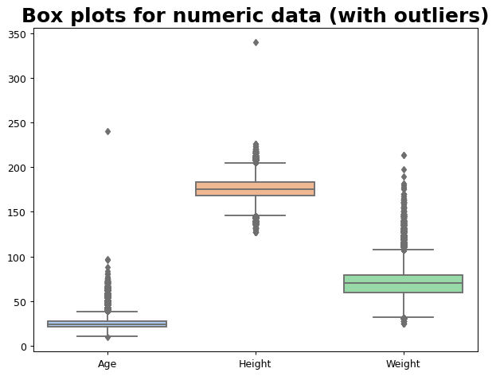

```python
# boxplots for numeric data
plt.figure(figsize=(8, 6), dpi=90)
plt.title("Box plots for numeric data (with outliers)", weight='bold', fontsize=20)
sns.boxplot(num_data, palette='pastel')
```

Obviously, there are outliers in our data. There are athlets with age near 250 years, or with height near 3.5 meters. For weight I decided to manualy check the kind of sports for outliers.

```python
data[data.Age > 200]
```

|  | ID | Name | Sex | Age | Height | Weight | Team | NOC | Games | Year | Season | City | Sport | Event | Medal |
| --- | --- | --- | --- | --- | --- | --- | --- | --- | --- | --- | --- | --- | --- | --- | --- |
| 112567 | 23459 | Flicien Jules mile Courbet | M | 240.0 | NaN | NaN | Belgium | BEL | 1912 Summer | 1912 | Summer | Stockholm | Swimming | Swimming Men's 200 metres Breaststroke | NaN |

```python
data[data.Age == 10]
```

|  | ID | Name | Sex | Age | Height | Weight | Team | NOC | Games | Year | Season | City | Sport | Event | Medal |
| --- | --- | --- | --- | --- | --- | --- | --- | --- | --- | --- | --- | --- | --- | --- | --- |
| 29405 | 71691 | Dimitrios Loundras | M | 10.0 | NaN | NaN | Ethnikos Gymnastikos Syllogos | GRE | 1896 Summer | 1896 | Summer | Athina | Gymnastics | Gymnastics Men's Parallel Bars, Teams | Bronze |

Unfortunately, it is not yet possible to be at the age of 240. It's strong outlier. On the other hand, there is no age limits for taking part in Olympic Games. So, 10-years-old boy in Gymnastics might be possible.

```python
data[data.Age > 90]
```

|  | ID | Name | Sex | Age | Height | Weight | Team | NOC | Games | Year | Season | City | Sport | Event | Medal |
| --- | --- | --- | --- | --- | --- | --- | --- | --- | --- | --- | --- | --- | --- | --- | --- |
| 53403 | 128719 | John Quincy Adams Ward | M | 97.0 | NaN | NaN | United States | USA | 1928 Summer | 1928 | Summer | Amsterdam | Art Competitions | Art Competitions Mixed Sculpturing, Statues | NaN |
| 74942 | 49663 | Winslow Homer | M | 96.0 | NaN | NaN | United States | USA | 1932 Summer | 1932 | Summer | Los Angeles | Art Competitions | Art Competitions Mixed Painting, Unknown Event | NaN |
| 112567 | 23459 | Flicien Jules mile Courbet | M | 240.0 | NaN | NaN | Belgium | BEL | 1912 Summer | 1912 | Summer | Stockholm | Swimming | Swimming Men's 200 metres Breaststroke | NaN |

Wow! Previously, I haven't heard about [Art Competitions](https://en.wikipedia.org/wiki/Art_competitions_at_the_Summer_Olympics) at the Summer Olympic Games. Let's keep the athletes of advanced age in our data.

```python
data[data.Height > 300]
```

|  | ID | Name | Sex | Age | Height | Weight | Team | NOC | Games | Year | Season | City | Sport | Event | Medal |
| --- | --- | --- | --- | --- | --- | --- | --- | --- | --- | --- | --- | --- | --- | --- | --- |
| 112756 | 23549 | Kirsty Leigh Coventry (-Seward) | F | 28.0 | 340.0 | 64.0 | Zimbabwe | ZIM | 2012 Summer | 2012 | Summer | London | Swimming | Swimming Women's 200 metres Individual Medley | NaN |

Hm, 3.4 m woman. Unfortunately, outlier.

```python
data[data.Weight > 180]
```

|  | ID | Name | Sex | Age | Height | Weight | Team | NOC | Games | Year | Season | City | Sport | Event | Medal |
| --- | --- | --- | --- | --- | --- | --- | --- | --- | --- | --- | --- | --- | --- | --- | --- |
| 1616 | 103159 | Aytami Ruano Vega | M | 27.0 | 200.0 | 198.0 | Spain | ESP | 2004 Summer | 2004 | Summer | Athina | Judo | Judo Men's Heavyweight | NaN |
| 100844 | 118869 | Christopher J. "Chris" Taylor | M | 22.0 | 196.0 | 182.0 | United States | USA | 1972 Summer | 1972 | Summer | Munich | Wrestling | Wrestling Men's Super-Heavyweight, Greco-Roman | NaN |
| 100845 | 118869 | Christopher J. "Chris" Taylor | M | 22.0 | 196.0 | 182.0 | United States | USA | 1972 Summer | 1972 | Summer | Munich | Wrestling | Wrestling Men's Super-Heavyweight, Freestyle | Bronze |
| 164917 | 38075 | Marek Galiski | M | 29.0 | 200.0 | 190.0 | Poland | POL | 1980 Summer | 1980 | Summer | Moskva | Wrestling | Wrestling Men's Super-Heavyweight, Greco-Roman | NaN |
| 203487 | 12177 | Ricardo Blas, Jr. | M | 21.0 | 183.0 | 214.0 | Guam | GUM | 2008 Summer | 2008 | Summer | Beijing | Judo | Judo Men's Heavyweight | NaN |
| 203488 | 12177 | Ricardo Blas, Jr. | M | 25.0 | 183.0 | 214.0 | Guam | GUM | 2012 Summer | 2012 | Summer | London | Judo | Judo Men's Heavyweight | NaN |

It seems OK for Judo and Wrestling Sports that athlets have the weight near 200 kg. Let's keep them in our data.

So, outliers can be detected using **visualization**, **implementing mathematical formulas** on the dataset, or using the **statistical approach**. The most popular graphs for outliers visualization are *box plot with whiskers*, *scatterplot*, and *histogram*. *Z- Score* helps to understand that how far is the data point from the mean. And after setting up a threshold value we can utilize z-score values of data points to define the outliers. ALso to finding the outliers the *Inter Quartile Range (IQR)* is the most commonly used. To define the outlier, base value is defined above and below datasets normal range namely Upper and Lower bounds, define the upper and the lower bound (1.5*IQR value is considered).

In this case, I removed fully duplicated observations, fixed some "bugs" such as the presence of non-existent sex value, visualized outliers using box plot and checked them manualy to determine the possibility of their occurrence. As I noticed, each outlier does not affect other athlet feachures, so, I decided to replace them with NaN, calculate the median, and set the *median value* instead of outliers.

```python
# setting median values for outliers
data.at[112756, 'Height'] = np.nan
data.at[112567, 'Age'] = np.nan
data.at[112756, 'Height'] = data.Height.median()
data.at[112567, 'Age'] = data.Age.median()
```

Now, let's visualize numeric data again.

```python
#describe the data
num_data2 = data[['Age', 'Height', 'Weight']] # subset with numeric values
num_data2.describe().round(2)
```

|  | Age | Height | Weight |
| --- | --- | --- | --- |
| count | 260406.00 | 210909.00 | 208196.00 |
| mean | 25.45 | 175.34 | 70.70 |
| std | 6.16 | 10.52 | 14.35 |
| min | 10.00 | 127.00 | 25.00 |
| 25% | 21.00 | 168.00 | 60.00 |
| 50% | 24.00 | 175.00 | 70.00 |
| 75% | 28.00 | 183.00 | 79.00 |
| max | 97.00 | 226.00 | 214.00 |

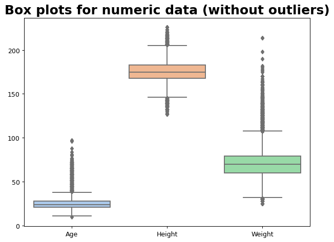

```python
# boxplots for numeric data
plt.figure(figsize=(8, 6), dpi=90)
plt.title("Box plots for numeric data (without outliers)", weight='bold', fontsize=20)
sns.boxplot(num_data2, palette='pastel')
```

```python
data.to_csv("processed_olympic_data.csv")
```

## Task3. What the age for the youngest Males and Females in 1992 Olympics?

```python
# the age of the youngest Olympic athlets in 1992
youngest_1992 = data[data.Year == 1992].groupby(['Sex']).min(['Age'])
youngest_1992
```

| Sex | Age | Height | Weight | Year |
| --- | --- | --- | --- | --- |
| F | 12.0 | 136.0 | 30.0 | 1992 |
| M | 11.0 | 140.0 | 45.0 | 1992 |

In 1992 Summer Olympic Games the youngest female and male was 12 and 11 years-old athletes, respectively.

## Task4. What are the mean and standart deviation for the both genders Height?

As long as many athletes have participated in multiple Olympics and Events, I think it is resonable to keep only one value for each athlet ID. Also we know that there is outliers for Height

```python
sex_height = data.drop_duplicates(['ID']).groupby(['Sex']).agg({'Height': ['mean', 'std']})
sex_height.round(2)
```

| Sex | Height mean | Height std |
| --- | --- | --- |
| F | 168.93 | 8.51 |
| M | 179.44 | 9.46 |

The mean *Height* for **Females** is $(168.93 \pm 8.51)$ and for **Males** is $(179.44 \pm 9.46)$.

## Task5. What are the mean and standart deviation for Female tennisists Height in 2000 Olympic Games?

The same way with previous task, I decided to drop duplicates by ID.

```python
height_fem_2000 = data.drop_duplicates(['ID']).loc[
    (data.Sex == 'F') & (data.Year == 2000) & (data.Sport == 'Tennis')
].agg(
    {'Height': ['mean', 'std']}
)
height_fem_2000.round(1)
```

|  | Height |
| --- | --- |
| mean | 172.4 |
| std | 6.4 |

So, *the mean Height for Female tennisists in 2000 Olympics Games* is $(172.4 \pm 6.4)$.

## Task6. What kind of sport in the 2006 Olympics Games did the most heavyweight athlete participate in?

```python
data.at[data.Weight[data.Year == 2006].idxmax(), 'Sport']
```

```
'Skeleton'
```

The most heavyweight athlete participated in the *Skeleton* in the 2006 Olympics Games.

## Task7. How many Gold medals did women win between 1980 and 2010?

For this taks I decided to include the period bounderies in calculations.

```python
years = np.arange(1980, 2011)
women_gold = data.query('Medal == "Gold" & Sex == "F"')
women_gold[women_gold['Year'].isin(years)].shape[0]
```

```
2249
```

```python
years = np.arange(1980, 2011)
men_gold = data.query('Medal == "Gold" & Sex == "M"')
men_gold[men_gold['Year'].isin(years)].shape[0]
```

```
3494
```

In 1980-2010 women won **2249 Gold medals**. I was also interested in Gold medals number for men. Hm, the difference in number is near 1200 medals.

## Task8. How many Olympic games has John Aalberg participated in?

```python
jaalberg_games = data[data.Name == 'John Aalberg'].Games.unique()
jaalberg_games
```

```
array(['1992 Winter', '1994 Winter'], dtype=object)
```

John Aalberg has participated in **two Winter Olympic Games** in 1992 and 1994 but in 8 Events.

## Task9. Which age groups are the most and the least abundant in the 2008 Olympics?

Let's group our data by Age groups, such as [10-15), [15-25), [25-35), [35-45), [45-55), [55-65), [65-70), and create column 'AgeGroup' for this age ranks. Also we need to take in account that each athlet could participate more then one Event (take only unique IDs).

```python
# subsetting for the 2008 Olympic Games
data_2008 = data[data.Year == 2008]
# setting age ranges
age_ranges = pd.IntervalIndex.from_arrays(
    [10, 15, 25, 35, 45, 55, 65],
    [15, 25, 35, 45, 55, 65, 70], closed='left'
)
# categorizing data by age groups
age_cat = pd.cut(data_2008['Age'], bins=age_ranges)
# inserting column 'AgeGroup'
data_2008.insert(4, 'AgeGroup', age_cat, True)
# counting number of athlets in each age group
age_groups_count = data_2008.groupby('AgeGroup').ID.nunique()
age_groups_count
```

```
AgeGroup
[10, 15)      13
[15, 25)    4786
[25, 35)    5382
[35, 45)     630
[45, 55)      76
[55, 65)      10
[65, 70)       1
Name: ID, dtype: int64
```

In the 2008 Olympic Games **the most of athlets** (5382 people) was in **the age from 25 to 35**, and **the 65-70 age group** was **the least abundant** with only one athlet.

## Task10. What is the difference between the number of Sports in the Olympic Games 1994 and 2002?

```python
data[data.Year == 2002].Sport.unique()
```

```
array(['Speed Skating', 'Freestyle Skiing', 'Ice Hockey', 'Bobsleigh',
       'Biathlon', 'Nordic Combined', 'Curling', 'Alpine Skiing', 'Luge',
       'Cross Country Skiing', 'Snowboarding',
       'Short Track Speed Skating', 'Figure Skating', 'Ski Jumping',
       'Skeleton'], dtype=object)
```

```python
data[data.Year == 1994].Sport.unique()
```

```
array(['Biathlon', 'Bobsleigh', 'Ice Hockey', 'Alpine Skiing',
       'Cross Country Skiing', 'Ski Jumping', 'Figure Skating',
       'Speed Skating', 'Nordic Combined', 'Luge', 'Freestyle Skiing',
       'Short Track Speed Skating'], dtype=object)
```

```python
data[data.Year == 2002].Sport.nunique() - data[data.Year == 1994].Sport.nunique()
```

```
3
```

In 2002 there were **three** new Winter Sports (Curling, Snowboarding, and Skeleton) as compared to the 1994 Olympic Games.

## Task11. Top 3 countries by different types of medals in the Summer and Winter Olympic Games

```python
# subsetting data by 'Season', 'Medal', and 'Team'
# and counting 'Medals' for each 'Team'
country_medals_subset = data.groupby(
    ['Season', 'Medal', 'Team']
).agg(
    n_Medals = ('Medal', 'count')
).reset_index(
    ['Season', 'Medal', 'Team']
)

# transforming 'Medal' to Categorical
medal_categories = ["Gold", "Silver", "Bronze"]
country_medals_subset['Medal'] = pd.Categorical(
    country_medals_subset['Medal'], categories = medal_categories
)

# getting top 3 countries indicies
country_medals_subset2 = country_medals_subset.groupby(
    ['Season', 'Medal'])['n_Medals'].nlargest(3).reset_index(
    ['Season', 'Medal'])

# resulted dataframe
top_countries = country_medals_subset.iloc[country_medals_subset2.index].sort_values(
    by=['Season', 'Medal']
).groupby(
    ['Season', 'Medal']
).head(3)
top_countries
```

|  | Season | Medal | Team | n_Medals |
| --- | --- | --- | --- | --- |
| 463 | Summer | Gold | United States | 2333 |
| 443 | Summer | Gold | Soviet Union | 830 |
| 335 | Summer | Gold | Germany | 564 |
| 716 | Summer | Silver | United States | 1241 |
| 679 | Summer | Silver | Soviet Union | 635 |
| 561 | Summer | Silver | Great Britain | 576 |
| 230 | Summer | Bronze | United States | 1112 |
| 86 | Summer | Bronze | Germany | 610 |
| 201 | Summer | Bronze | Soviet Union | 596 |
| 804 | Winter | Gold | Canada | 289 |
| 838 | Winter | Gold | Soviet Union | 228 |
| 831 | Winter | Gold | Norway | 151 |
| 916 | Winter | Silver | United States | 271 |
| 862 | Winter | Silver | Canada | 189 |
| 898 | Winter | Silver | Norway | 165 |
| 754 | Winter | Bronze | Finland | 215 |
| 784 | Winter | Bronze | Sweden | 177 |
| 773 | Winter | Bronze | Norway | 127 |

The resulted `top_countries` dataframe contains **18 top countries** sorted by number of Medals and Medal type for both Seasons.

## Task12. Athlets' Heights standardization

For this Task I created new variable **Height_z_scores** for athlets' Heights standartization and added it into subset `athlets_features`.

```python
# subsetting data with some athlets features
athlets_features = data[data.columns[0:8]]
athlets_features
```

|  | ID | Name | Sex | Age | Height | Weight | Team | NOC |
| --- | --- | --- | --- | --- | --- | --- | --- | --- |
| 0 | 102344 | Yosmany Romero Rodrguez | M | 24.0 | 180.0 | 76.0 | Cuba | CUB |
| 1 | 102345 | Francisco Romero Arribas | M | 16.0 | 178.0 | 64.0 | Guatemala | GUA |
| 2 | 102345 | Francisco Romero Arribas | M | 20.0 | 178.0 | 64.0 | Guatemala | GUA |
| 3 | 102345 | Francisco Romero Arribas | M | 24.0 | 178.0 | 64.0 | Guatemala | GUA |
| 4 | 102345 | Francisco Romero Arribas | M | 32.0 | 178.0 | 64.0 | Guatemala | GUA |
| ... | ... | ... | ... | ... | ... | ... | ... | ... |
| 271100 | 102339 | Sergio Germn Romero | M | 21.0 | 191.0 | 86.0 | Argentina | ARG |
| 271101 | 102340 | Sigrid Romero Duque | F | 19.0 | 164.0 | 57.0 | Colombia | COL |
| 271102 | 102340 | Sigrid Romero Duque | F | 19.0 | 164.0 | 57.0 | Colombia | COL |
| 271103 | 102341 | Susana Romero Steensma | F | 17.0 | 173.0 | 64.0 | Spain | ESP |
| 271104 | 102342 | Yasmani Jess Romero Rodrguez | M | 23.0 | NaN | NaN | Cuba | CUB |

269720 rows × 8 columns

```python
# calculating Height zscores and putting them into Height_z_scores column
Height_z_scores = zscore(athlets_features.Height, nan_policy = 'omit')
athlets_features.insert(5, column='Height_z_scores', value = Height_z_scores)
```

```python
athlets_features
```

|  | ID | Name | Sex | Age | Height | Height_z_scores | Weight | Team | NOC |
| --- | --- | --- | --- | --- | --- | --- | --- | --- | --- |
| 0 | 102344 | Yosmany Romero Rodrguez | M | 24.0 | 180.0 | 0.443108 | 76.0 | Cuba | CUB |
| 1 | 102345 | Francisco Romero Arribas | M | 16.0 | 178.0 | 0.252969 | 64.0 | Guatemala | GUA |
| 2 | 102345 | Francisco Romero Arribas | M | 20.0 | 178.0 | 0.252969 | 64.0 | Guatemala | GUA |
| 3 | 102345 | Francisco Romero Arribas | M | 24.0 | 178.0 | 0.252969 | 64.0 | Guatemala | GUA |
| 4 | 102345 | Francisco Romero Arribas | M | 32.0 | 178.0 | 0.252969 | 64.0 | Guatemala | GUA |
| ... | ... | ... | ... | ... | ... | ... | ... | ... | ... |
| 271100 | 102339 | Sergio Germn Romero | M | 21.0 | 191.0 | 1.488876 | 86.0 | Argentina | ARG |
| 271101 | 102340 | Sigrid Romero Duque | F | 19.0 | 164.0 | -1.078008 | 57.0 | Colombia | COL |
| 271102 | 102340 | Sigrid Romero Duque | F | 19.0 | 164.0 | -1.078008 | 57.0 | Colombia | COL |
| 271103 | 102341 | Susana Romero Steensma | F | 17.0 | 173.0 | -0.222380 | 64.0 | Spain | ESP |
| 271104 | 102342 | Yasmani Jess Romero Rodrguez | M | 23.0 | NaN | NaN | NaN | Cuba | CUB |

269720 rows × 9 columns

## Task13. Athlets' Heights min-max normalization

```python
Height_min_max_scaled = (athlets_features.Height - athlets_features.Height.min())/\
                        (athlets_features.Height.max() - athlets_features.Height.min())
athlets_features.insert(6, column='Height_min_max_scaled', value = Height_min_max_scaled)
```

```python
athlets_features
```

|  | ID | Name | Sex | Age | Height | Height_z_scores | Height_min_max_scaled | Weight | Team | NOC |
| --- | --- | --- | --- | --- | --- | --- | --- | --- | --- | --- |
| 0 | 102344 | Yosmany Romero Rodrguez | M | 24.0 | 180.0 | 0.443108 | 0.535354 | 76.0 | Cuba | CUB |
| 1 | 102345 | Francisco Romero Arribas | M | 16.0 | 178.0 | 0.252969 | 0.515152 | 64.0 | Guatemala | GUA |
| 2 | 102345 | Francisco Romero Arribas | M | 20.0 | 178.0 | 0.252969 | 0.515152 | 64.0 | Guatemala | GUA |
| 3 | 102345 | Francisco Romero Arribas | M | 24.0 | 178.0 | 0.252969 | 0.515152 | 64.0 | Guatemala | GUA |
| 4 | 102345 | Francisco Romero Arribas | M | 32.0 | 178.0 | 0.252969 | 0.515152 | 64.0 | Guatemala | GUA |
| ... | ... | ... | ... | ... | ... | ... | ... | ... | ... | ... |
| 271100 | 102339 | Sergio Germn Romero | M | 21.0 | 191.0 | 1.488876 | 0.646465 | 86.0 | Argentina | ARG |
| 271101 | 102340 | Sigrid Romero Duque | F | 19.0 | 164.0 | -1.078008 | 0.373737 | 57.0 | Colombia | COL |
| 271102 | 102340 | Sigrid Romero Duque | F | 19.0 | 164.0 | -1.078008 | 0.373737 | 57.0 | Colombia | COL |
| 271103 | 102341 | Susana Romero Steensma | F | 17.0 | 173.0 | -0.222380 | 0.464646 | 64.0 | Spain | ESP |
| 271104 | 102342 | Yasmani Jess Romero Rodrguez | M | 23.0 | NaN | NaN | NaN | NaN | Cuba | CUB |

269720 rows × 10 columns

## Task14. Athlets' Height, Weight and Age comparison between men and women in the Winter Olympics Games

For this Task I created subset with appropriate features, performed t-test, and visualized results.

```python
# subsetting data for the Winter Olympic Games by 'Sex','Age', 'Height', and 'Weight'
df_comparison = data[data['Season'] == 'Winter'][
    ['ID','Sex','Age','Height','Weight']
].drop_duplicates().drop(columns=['ID'])
df_comparison
```

|  | Sex | Age | Height | Weight |
| --- | --- | --- | --- | --- |
| 24 | M | 27.0 | 177.0 | 80.0 |
| 25 | M | 31.0 | 177.0 | 80.0 |
| 26 | M | 24.0 | 190.0 | 85.0 |
| 28 | M | 28.0 | 190.0 | 85.0 |
| 31 | M | 21.0 | 185.0 | 80.0 |
| ... | ... | ... | ... | ... |
| 270978 | F | 29.0 | 168.0 | 60.0 |
| 270981 | M | 24.0 | NaN | NaN |
| 270993 | F | 22.0 | NaN | NaN |
| 271006 | M | 33.0 | NaN | NaN |
| 271007 | M | 37.0 | NaN | NaN |

28582 rows × 4 columns

```python
# female group
fem_group = df_comparison[df_comparison.Sex == 'F']
# male group
male_group = df_comparison[df_comparison.Sex == 'M']
```

```python
# mean and std for Sex groups
df_comparison.groupby(['Sex']).agg(['mean', 'std']).round(2)
```

| Sex | Age mean | Age std | Height mean | Height std | Weight mean | Weight std |
| --- | --- | --- | --- | --- | --- | --- |
| F | 23.71 | 4.88 | 166.32 | 6.29 | 60.01 | 7.78 |
| M | 25.65 | 4.88 | 178.94 | 6.66 | 77.89 | 10.61 |

```python
# t-test for Age
ttest_ind(fem_group.Age, male_group.Age, equal_var=False, nan_policy = 'omit')
```

```
Ttest_indResult(statistic=-30.220677600615726, pvalue=1.0334920356612475e-194)
```

```python
# t-test for Height
ttest_ind(fem_group.Height, male_group.Height, equal_var=False, nan_policy = 'omit')
```

```
Ttest_indResult(statistic=-138.87747101396914, pvalue=0.0)
```

```python
# t-test for Weight
ttest_ind(fem_group.Weight, male_group.Weight, equal_var=False, nan_policy = 'omit')
```

```
Ttest_indResult(statistic=-142.80960604623098, pvalue=0.0)
```

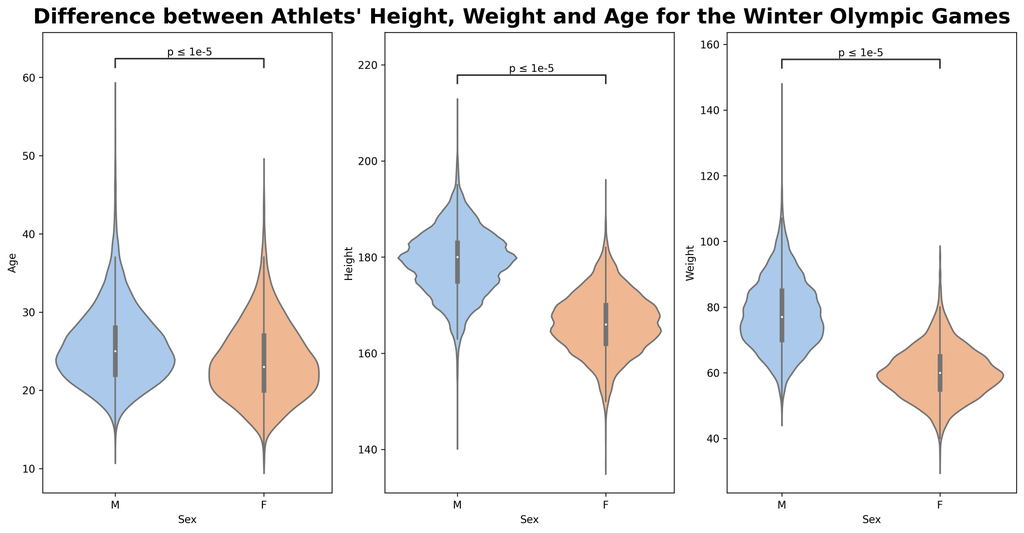

```python
# violin plots
cols = ['Age','Height','Weight']
fig, axs = plt.subplots(1, 3, figsize=(14,7), dpi=300)
fig.tight_layout(pad=2.0)

fig.suptitle("Difference between Athlets' Height, Weight and Age for the Winter Olympic Games", weight='bold', fontsize=20, y=1)
for i, ax in enumerate(axs):
    sns.violinplot(x= 'Sex', y=cols[i] ,ax=ax, data=df_comparison, orient='v', palette="pastel")
    # add_stat_annotation() function from package 'statannot'
    add_stat_annotation(ax, data=df_comparison, x='Sex', y=cols[i],
                        box_pairs=[('M', 'F')],
                        test='t-test_ind', text_format='simple', loc='inside', verbose=0)
```

## Task15. Are Team and Medal features independent?

In order to check I performed Chi-square test. For this test I decided to filter Teams that have at least 5 of each type of medals.

```python
# creating appropriate dataframe
df = pd.crosstab(index=data['Team'],columns=data['Medal'])
df = df[(df>=5).sum(axis=1) == 3]
CrosstabResult = df
CrosstabResult
```

| Medal Team | Bronze | Gold | Silver |
| --- | --- | --- | --- |
| Argentina | 91 | 91 | 84 |
| Australia | 511 | 342 | 453 |
| Austria | 150 | 95 | 168 |
| Azerbaijan | 25 | 7 | 12 |
| Bahamas | 13 | 12 | 11 |
| ... | ... | ... | ... |
| United States-1 | 30 | 38 | 33 |
| United States-2 | 20 | 17 | 14 |
| Uzbekistan | 17 | 10 | 7 |
| West Germany | 219 | 155 | 184 |
| Yugoslavia | 93 | 130 | 167 |

79 rows × 3 columns

79 teams passed filtering and won all kinds of medals. What does the Chi-square test say?

```python
# Chi-square test using chi2_contingency()
ChiSqResult = chi2_contingency(CrosstabResult)
pval = ChiSqResult[1]
print(f'ChiSq test p-value: {pval}')
print('Variables are' +' not'*int(pval > 0.05) + ' correlated!') # Just for fun.
```

```
ChiSq test p-value: 1.6409085459751247e-256
Variables are correlated!
```

With grate certainty we can say that not all Teams are equal. Some of them have won medals of certain kind more frequently then others.

## Additional Task16. Testing hypothesis

- Is it possible that Summer Olympics Athlets are slimmer than the Winter Olympics Athlets?

```
Winter Olympics Athlets average BMI: 23.42, Summer Olympics Athlets BMI: 22.868968138183543
Ttest_indResult(statistic=20.154066503150617, pvalue=3.752938750352067e-90)
```

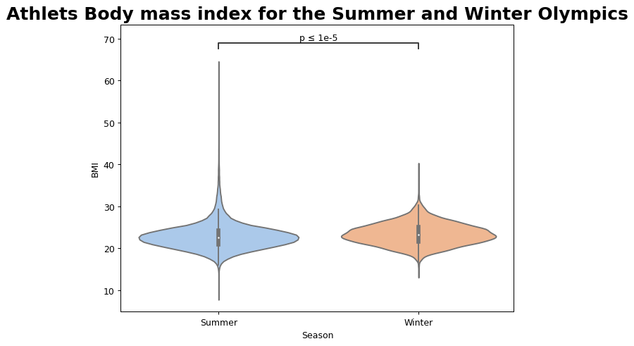

```python
# BMI - Body mass index - mass(kg)/height(m)^2.
data['BMI'] = data['Weight']/(data['Height']*.01)**2

first = data[data['Season'] == 'Winter'].drop_duplicates('ID')['BMI']
second = data[data['Season'] == 'Summer'].drop_duplicates('ID')['BMI']

fig, ax = plt.subplots(figsize=(8, 6), dpi=90)
plt.title("Athlets Body mass index for the Summer and Winter Olympics", weight='bold', fontsize=20)
sns.violinplot(x= 'Season', y='BMI', data=data.drop_duplicates('ID'), orient='v', palette='pastel')
add_stat_annotation(ax=ax, data=data.drop_duplicates('ID'), x='Season', y='BMI',
                    box_pairs=[('Summer', 'Winter')],
                    test='t-test_ind', text_format='simple', loc='inside', verbose=0)
print(f'Winter Olympics Athlets average BMI: {round(first.mean(), 2)}, Summer Olympics Athlets BMI: {second.mean()}')
print(ttest_ind(first, second, nan_policy='omit'))
```

Yes! The Summer Olympics Athlets have lower BMI with hight significance (t-test p-value < $1e^{-5}$) but averagely all of them are lean and beautifull:)

- Now let's do this for Male and Female Athlets. BMI for Male Athlets is significantly higher then for Female Athlets (t-test p-value < $1e^{-5}$).

```
Male average BMI: 23.62, Female average BMI: 21.37
Ttest_indResult(statistic=113.77080371132904, pvalue=0.0)
```

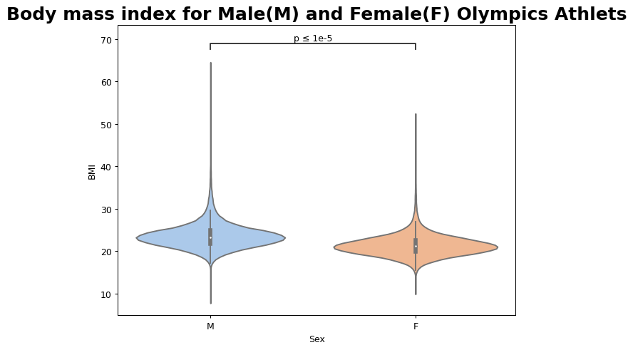

```python
# subsetting data
first = data[data['Sex'] == 'M'].drop_duplicates('ID')['BMI']
second = data[data['Sex'] == 'F'].drop_duplicates('ID')['BMI']

fig, ax = plt.subplots(figsize=(8, 6), dpi=90)
plt.title("Body mass index for Male(M) and Female(F) Olympics Athlets", weight='bold', fontsize=20)
sns.violinplot(x= 'Sex', y='BMI', data=data.drop_duplicates('ID'), orient='v', palette='pastel')
add_stat_annotation(ax=ax, data=data.drop_duplicates('ID'), x='Sex', y='BMI',
                    box_pairs=[('M', 'F')],
                    test='t-test_ind', text_format='simple', loc='inside', verbose=0)

print(f'Male average BMI: {round(first.mean(), 2)}, Female average BMI: {round(second.mean(), 2)}')
print(ttest_ind(first, second, nan_policy='omit'))
```

- Is it true that female figure skaters are getting younger every year? Surprisingly, it's more complicated. Even though average age is decreasing now, global minimum was in the 1960th.

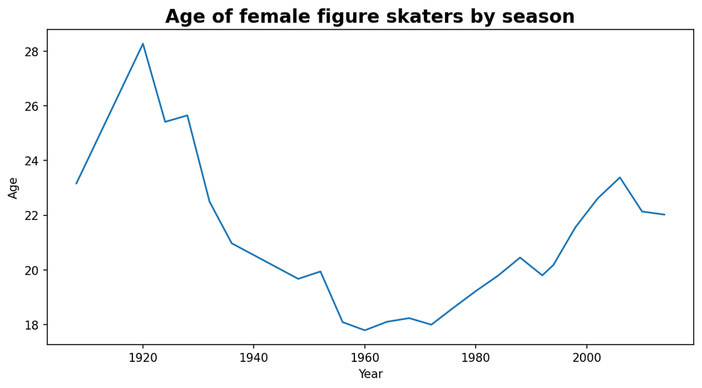

```python
# subsetting data
df = data[(data['Sport'] == 'Figure Skating') & (
    data['Sex'] == 'F')].drop_duplicates(
    ['ID','Year']).groupby('Year')['Age'].mean()

fig, ax = plt.subplots(dpi=150)
plt.title('Age of female figure skaters by season', fontweight='bold', fontsize=16)
df.plot(figsize=(10,5), ylabel='Age')
```